# Diabetes Classification

Sharif Ashna - 99103633

2023 May

# Introduction

Nearly half a billion people worldwide live with diabetes, and nearly 80% of those live in low- and middle-income countries. Nine in ten people with diabetes have Type 2 diabetes, which is increasing fastest in low- and middle-income countries. Diabetes increases the risk of early death, and diabetes-related complications can lower quality of life. The high global burden of diabetes has a negative economic impact on individuals, health care systems, and nations.

Complications like heart disease, vision loss, lower-limb amputation, and kidney disease are associated with chronically high levels of sugar remaining in the bloodstream for those with diabetes. While there is no cure for diabetes, strategies like losing weight, eating healthily, being active, and receiving medical treatments can mitigate the harms of this disease in many patients. Early diagnosis can lead to lifestyle changes and more effective treatment, making predictive models for diabetes risk important tools for public and public health officials. The scale of this problem is also important to recognize. The Centers for Disease Control and Prevention has indicated that as of 2018, 34.2 million Americans have diabetes and 88 million have prediabetes. Furthermore, the CDC estimates that 1 in 5 diabetics, and roughly 8 in 10 pre diabetics are unaware of their risk. While there are different types of diabetes, type II diabetes is the most common form and its prevalence varies by age, education, income, location, race, and other social determinants of health. Much of the burden of the disease falls on those of lower socioeconomic status as well. Diabetes also places a massive burden on the economy, with diagnosed diabetes costs of roughly $327 billion dollars and total costs with undiagnosed diabetes and prediabetes approaching $400 billion dollars annually. So, it’s important to identify and detect the people who might have diabetes or are in risk of having one. To do so, we gather information on the patients and probable cases. We consider 21 factors that may relate to having diabetes. Here we have records of 253680 of patients who lives in America based on the survey conducted by CDC – Center of Disease Control and Prevention – annually. Another dataset we use here is a clean dataset of 70,692 survey responses which has an equal 50-50 split of respondents with no diabetes and with either prediabetes or diabetes. Both of the dataset have binary responses.

# Problems

1. The first problem is “is this worth trying”? does any of the features have any connection with diabetes?
2. The second problem that we need to address here is what are the most important factors for detecting diabetes?
3. The Third problem is if we can use a subset of features instead of using all of them?
4. the fourth problem is how we actually model and what features we use for prediction?

before we start, we load the datasets and required libraries on to our code

```r
# required libraries

library(rmarkdown)
library(data.table)
library(grid)
library(caret)
library(tidyverse)
library(MASS)
library(ISLR2)
library(pls)
library(FSelector)
library(rpart)
library(rpart.plot)
library(glmnet)

#loading datasets

path = choose.files()
d = read.csv(path)
path2 = choose.files()
d2 = read.csv(path2)
```

Before starting, let’s take a glance at datasets in hand. as you can see, all the predictors except ‘BMI’ are qualitative. for further information about the features you can visit the source page [here.](https://www.kaggle.com/datasets/alexteboul/diabetes-health-indicators-dataset)

```r
head(d, 5)
```

```
##   Diabetes_binary HighBP HighChol CholCheck BMI Smoker Stroke HeartDiseaseorAttack PhysActivity Fruits Veggies
## 1               0      1        0         1  26      0      0                    0            1      0       1
## 2               0      1        1         1  26      1      1                    0            0      1       0
## 3               0      0        0         1  26      0      0                    0            1      1       1
## 4               0      1        1         1  28      1      0                    0            1      1       1
## 5               0      0        0         1  29      1      0                    0            1      1       1
##   HvyAlcoholConsump AnyHealthcare NoDocbcCost GenHlth MentHlth PhysHlth DiffWalk Sex Age Education Income
## 1                 0             1           0       3        5       30        0   1   4         6      8
## 2                 0             1           0       3        0        0        0   1  12         6      8
## 3                 0             1           0       1        0       10        0   1  13         6      8
## 4                 0             1           0       3        0        3        0   1  11         6      8
## 5                 0             1           0       2        0        0        0   0   8         5      8
```

```r
head(d2, 5)
```

```
##   Diabetes_binary HighBP HighChol CholCheck BMI Smoker Stroke HeartDiseaseorAttack PhysActivity Fruits Veggies
## 1               0      1        1         1  40      1      0                    0            0      0       1
## 2               0      0        0         0  25      1      0                    0            1      0       0
## 3               0      1        1         1  28      0      0                    0            0      1       0
## 4               0      1        0         1  27      0      0                    0            1      1       1
## 5               0      1        1         1  24      0      0                    0            1      1       1
##   HvyAlcoholConsump AnyHealthcare NoDocbcCost GenHlth MentHlth PhysHlth DiffWalk Sex Age Education Income
## 1                 0             1           0       5       18       15        1   0   9         4      3
## 2                 0             0           1       3        0        0        0   0   7         6      1
## 3                 0             1           1       5       30       30        1   0   9         4      8
## 4                 0             1           0       2        0        0        0   0  11         3      6
## 5                 0             1           0       2        3        0        0   0  11         5      4
```

# First Problem

To address the first problem, we use basic graphs and plots to show a connection between response and some of the features

Based on these simple plots we can see that Diabetes at least is connected with some of features here.

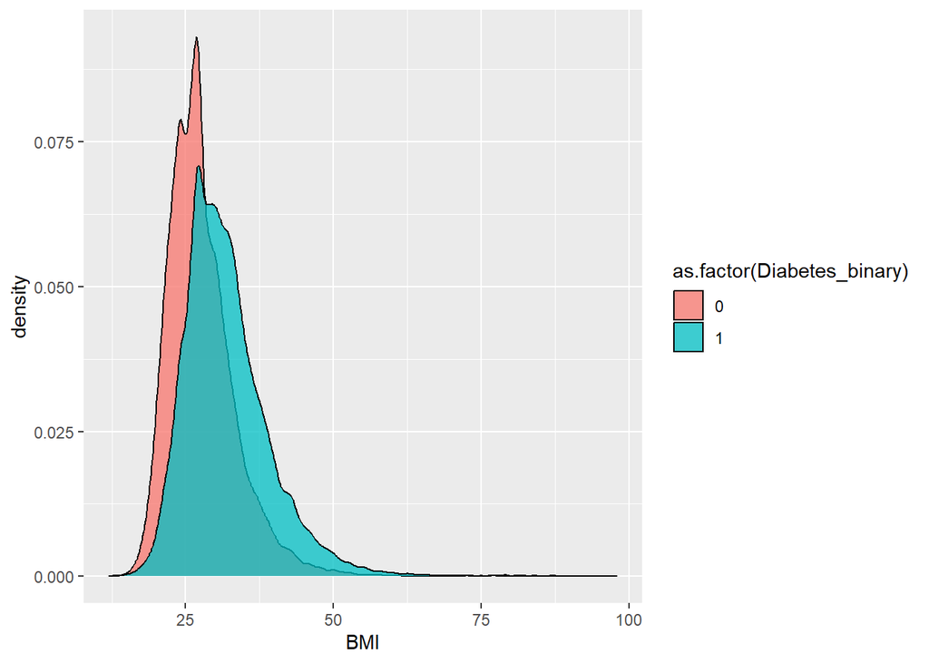

```r
ggplot(d, aes(x = BMI, fill = as.factor(Diabetes_binary))) + geom_density(alpha = 0.75)
```

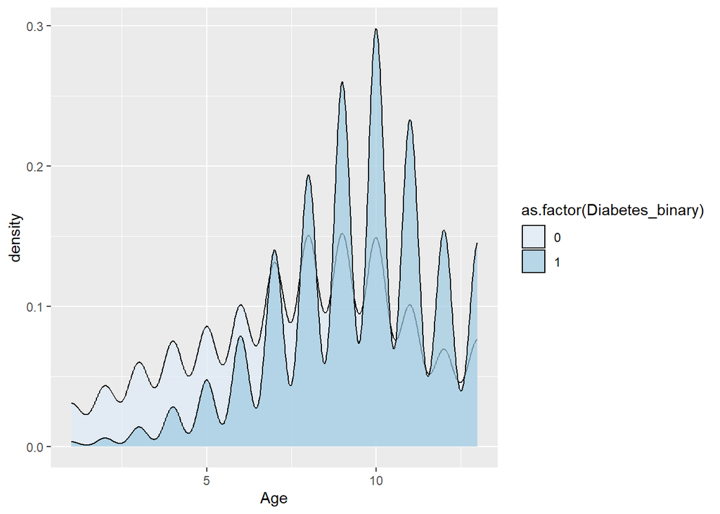

```r
e = ggplot(d, aes(x = Age, fill = as.factor(Diabetes_binary))) + geom_density(alpha = 0.7)
e + scale_fill_brewer(palette = 'Blues')
```

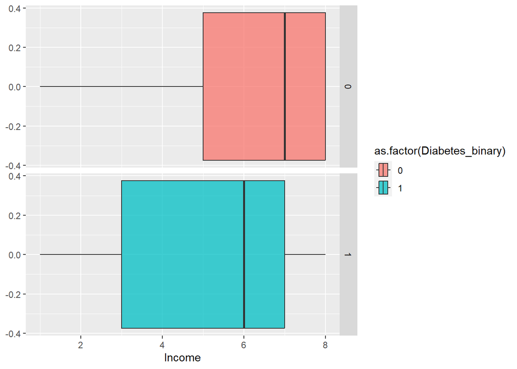

```r
ggplot(d, aes(x = Income, fill = as.factor(Diabetes_binary))) + geom_boxplot(alpha = 0.75)+
  facet_grid(Diabetes_binary ~ .) + labs(x = 'Income')
```

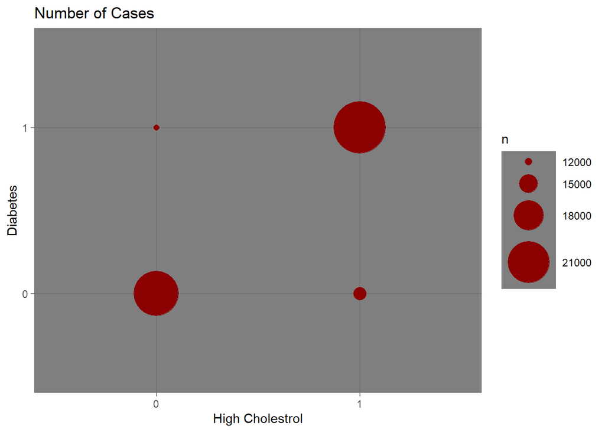

```r
ggplot(d, aes(x = as.factor(HighChol), y = as.factor(Diabetes_binary))) + geom_count(color = 'darkred') +
  theme_dark() + labs(x = 'High Cholestrol', y = 'Diabetes', title = 'Number of Cases') + scale_radius(range = c(2,20))
```

Correlation Matrix of Features

```r
a = data.frame(cor(d))
a[1:5,1:5]
```

```
##                 Diabetes_binary    HighBP  HighChol  CholCheck        BMI
## Diabetes_binary       1.0000000 0.3815155 0.2892128 0.11538162 0.29337274
## HighBP                0.3815155 1.0000000 0.3165148 0.10328329 0.24101856
## HighChol              0.2892128 0.3165148 1.0000000 0.08598140 0.13130949
## CholCheck             0.1153816 0.1032833 0.0859814 1.00000000 0.04564752
## BMI                   0.2933727 0.2410186 0.1313095 0.04564752 1.00000000
```

# Second Problem

The easiest way to find that which of the features is important is to use the Logistic Regression coefficients of each feature

```r
glm.fit = glm(Diabetes_binary ~ HighBP + HighChol + CholCheck + BMI + Smoker + Stroke + HeartDiseaseorAttack +
                PhysActivity + Fruits + Veggies + HvyAlcoholConsump + AnyHealthcare + NoDocbcCost + GenHlth + MentHlth +
                PhysHlth + DiffWalk + Sex + Age + Education + Income,family = binomial, data = d)

# another method for full model

glm.fit = glm(d$Diabetes_binary ~ ., family = binomial, data = d)
summary(glm.fit)
```

```
##
## Call:
## glm(formula = d$Diabetes_binary ~ ., family = binomial, data = d)
##
## Deviance Residuals:
##     Min       1Q   Median       3Q      Max
## -3.5606  -0.8050  -0.0186   0.8388   2.9678
##
## Coefficients:
##                       Estimate Std. Error z value Pr(>|z|)
## (Intercept)          -6.865139   0.124479 -55.151  < 2e-16 ***
## HighBP                0.735319   0.019738  37.255  < 2e-16 ***
## HighChol              0.587302   0.018861  31.139  < 2e-16 ***
## CholCheck             1.360832   0.081318  16.735  < 2e-16 ***
## BMI                   0.075617   0.001573  48.057  < 2e-16 ***
## Smoker               -0.001680   0.018875  -0.089 0.929075
## Stroke                0.162029   0.040917   3.960 7.50e-05 ***
## HeartDiseaseorAttack  0.252675   0.028435   8.886  < 2e-16 ***
## PhysActivity         -0.033131   0.021294  -1.556 0.119726
## Fruits               -0.034507   0.019592  -1.761 0.078185 .
## Veggies              -0.061051   0.023333  -2.616 0.008884 **
## HvyAlcoholConsump    -0.749713   0.048762 -15.375  < 2e-16 ***
## AnyHealthcare         0.060813   0.047164   1.289 0.197264
## NoDocbcCost           0.018988   0.034083   0.557 0.577452
## GenHlth               0.584617   0.011447  51.071  < 2e-16 ***
## MentHlth             -0.004360   0.001285  -3.394 0.000688 ***
## PhysHlth             -0.008321   0.001192  -6.981 2.94e-12 ***
## DiffWalk              0.114941   0.025861   4.445 8.81e-06 ***
## Sex                   0.267261   0.019150  13.956  < 2e-16 ***
## Age                   0.152242   0.003909  38.950  < 2e-16 ***
## Education            -0.036815   0.010221  -3.602 0.000316 ***
## Income               -0.058807   0.005193 -11.325  < 2e-16 ***
## ---
## Signif. codes:  0 '***' 0.001 '**' 0.01 '*' 0.05 '.' 0.1 ' ' 1
##
## (Dispersion parameter for binomial family taken to be 1)
##
##     Null deviance: 98000  on 70691  degrees of freedom
## Residual deviance: 72388  on 70670  degrees of freedom
## AIC: 72432
##
## Number of Fisher Scoring iterations: 5
```

here we can see which features are not actually related to the response

```r
q = data.frame(summary(glm.fit)$coef)
q$Pr...z.. = round(q$Pr...z.., 9)
head(q, 10)
```

```
##                          Estimate  Std..Error      z.value    Pr...z..
## (Intercept)          -6.865139269 0.124478686 -55.15112276 0.000000000
## HighBP                0.735319028 0.019737524  37.25487699 0.000000000
## HighChol              0.587302149 0.018860591  31.13911682 0.000000000
## CholCheck             1.360831820 0.081317658  16.73476415 0.000000000
## BMI                   0.075617321 0.001573492  48.05701972 0.000000000
## Smoker               -0.001680082 0.018875449  -0.08900885 0.929074874
## Stroke                0.162029275 0.040916946   3.95995525 0.000074964
## HeartDiseaseorAttack  0.252674886 0.028434536   8.88619698 0.000000000
## PhysActivity         -0.033131397 0.021293683  -1.55592606 0.119725675
## Fruits               -0.034507381 0.019591808  -1.76131685 0.078184789
```

```r
q[c(which(q$Pr...z.. > 0.05)),]
```

```
##                   Estimate Std..Error     z.value   Pr...z..
## Smoker        -0.001680082 0.01887545 -0.08900885 0.92907487
## PhysActivity  -0.033131397 0.02129368 -1.55592606 0.11972568
## Fruits        -0.034507381 0.01959181 -1.76131685 0.07818479
## AnyHealthcare  0.060813147 0.04716444  1.28938543 0.19726413
## NoDocbcCost    0.018987779 0.03408260  0.55711065 0.57745183
```

```r
#after discarding features
glm.fit2 = glm(Diabetes_binary ~ HighBP + HighChol + CholCheck + BMI + Stroke + HeartDiseaseorAttack +
                 Veggies + HvyAlcoholConsump + GenHlth + MentHlth +
                 PhysHlth + DiffWalk + Sex + Age + Education + Income,family = binomial, data = d)

summary(glm.fit2)
```

```
##
## Call:
## glm(formula = Diabetes_binary ~ HighBP + HighChol + CholCheck +
##     BMI + Stroke + HeartDiseaseorAttack + Veggies + HvyAlcoholConsump +
##     GenHlth + MentHlth + PhysHlth + DiffWalk + Sex + Age + Education +
##     Income, family = binomial, data = d)
##
## Deviance Residuals:
##     Min       1Q   Median       3Q      Max
## -3.5668  -0.8049  -0.0183   0.8385   2.9643
##
## Coefficients:
##                       Estimate Std. Error z value Pr(>|z|)
## (Intercept)          -6.856551   0.118007 -58.103  < 2e-16 ***
## HighBP                0.735943   0.019734  37.292  < 2e-16 ***
## HighChol              0.588572   0.018836  31.248  < 2e-16 ***
## CholCheck             1.363115   0.080966  16.836  < 2e-16 ***
## BMI                   0.075937   0.001567  48.455  < 2e-16 ***
## Stroke                0.161864   0.040906   3.957 7.59e-05 ***
## HeartDiseaseorAttack  0.252384   0.028392   8.889  < 2e-16 ***
## Veggies              -0.073674   0.022700  -3.246 0.001172 **
## HvyAlcoholConsump    -0.746021   0.048532 -15.372  < 2e-16 ***
## GenHlth               0.586580   0.011397  51.466  < 2e-16 ***
## MentHlth             -0.004243   0.001278  -3.319 0.000902 ***
## PhysHlth             -0.008193   0.001188  -6.893 5.44e-12 ***
## DiffWalk              0.120657   0.025672   4.700 2.60e-06 ***
## Sex                   0.268049   0.018910  14.175  < 2e-16 ***
## Age                   0.152256   0.003816  39.901  < 2e-16 ***
## Education            -0.038072   0.010122  -3.761 0.000169 ***
## Income               -0.058687   0.005128 -11.445  < 2e-16 ***
## ---
## Signif. codes:  0 '***' 0.001 '**' 0.01 '*' 0.05 '.' 0.1 ' ' 1
##
## (Dispersion parameter for binomial family taken to be 1)
##
##     Null deviance: 98000  on 70691  degrees of freedom
## Residual deviance: 72396  on 70675  degrees of freedom
## AIC: 72430
##
## Number of Fisher Scoring iterations: 5
```

```r
q2 = data.frame(summary(glm.fit2)$coef)
q2$Pr...z.. = round(q2$Pr...z.., 9)
head(q2, 10)
```

```
##                         Estimate  Std..Error    z.value    Pr...z..
## (Intercept)          -6.85655112 0.118007300 -58.102771 0.000000000
## HighBP                0.73594302 0.019734401  37.292392 0.000000000
## HighChol              0.58857214 0.018835536  31.247963 0.000000000
## CholCheck             1.36311544 0.080965748  16.835705 0.000000000
## BMI                   0.07593750 0.001567162  48.455424 0.000000000
## Stroke                0.16186373 0.040906487   3.956921 0.000075922
## HeartDiseaseorAttack  0.25238387 0.028392101   8.889228 0.000000000
## Veggies              -0.07367424 0.022700057  -3.245553 0.001172228
## HvyAlcoholConsump    -0.74602139 0.048532281 -15.371653 0.000000000
## GenHlth               0.58658021 0.011397389  51.466193 0.000000000
```

```r
q2[c(which(q2$Pr...z.. > 0.05)),]
```

```
## [1] Estimate   Std..Error z.value    Pr...z..
## <0 rows> (or 0-length row.names)
```

highest estimate

```r
q2[which.max(abs(q$Estimate[-1]))+1,]
```

```
##           Estimate Std..Error z.value Pr...z..
## CholCheck 1.363115 0.08096575 16.8357        0
```

# Third Problem

another method for feature importance is to use Chi square test and information gain criteria

```r
# Fselector for feature importance
#Chi_square
chi = chi.squared(Diabetes_binary ~ ., data = d)
features = cbind(chi,names(d)[-1])
features = features[order(features$attr_importance, decreasing = TRUE),]
features = data.table(features)
names(features) = c('Importance', 'attribute')
head(features,5)
```

```
##    Importance            attribute
## 1:  0.3393761               HighBP
## 2:  0.2599196             HighChol
## 3:  0.2437883             DiffWalk
## 4:  0.2163818              GenHlth
## 5:  0.1935462 HeartDiseaseorAttack
```

```r
print('based on Chi-square')
```

```
## [1] "based on Chi-square"
```

```r
#information gain
IG = information.gain(Diabetes_binary ~ ., data = d)
features2 = cbind(IG,names(d)[-1])
features2 = features2[order(features2$attr_importance, decreasing = TRUE),]
features2 = data.table(features2)
names(features2) = c('Importance', 'attribute')
head(features2,5)
```

```
##    Importance attribute
## 1: 0.07496633   GenHlth
## 2: 0.05919864    HighBP
## 3: 0.04725047       BMI
## 4: 0.03615182       Age
## 5: 0.03428035  HighChol
```

```r
print('based on IG')
```

```
## [1] "based on IG"
```

Shrinkage is a method for estimating coefficients and reducing variance at the same time

here we use ‘The Lasso’ for such a thing.

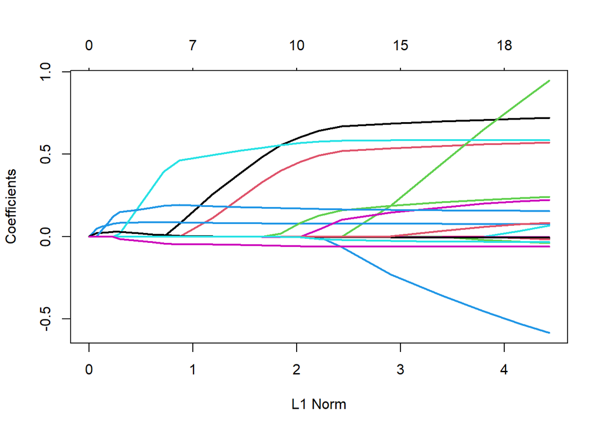

```r
# lasso coef
x = model.matrix(Diabetes_binary ~., data = d, family = binomial)
y = d$Diabetes_binary
grid = 10^seq(10,-3, length = 100)
lasso.mod = glmnet(x,y,alpha = 1, lambda = grid,family = 'binomial', standardize = FALSE)
plot(lasso.mod, lwd = 2)
```

In the mean time we need to determine the best tuning parameter for lasso. To do so, we use cross validation method.

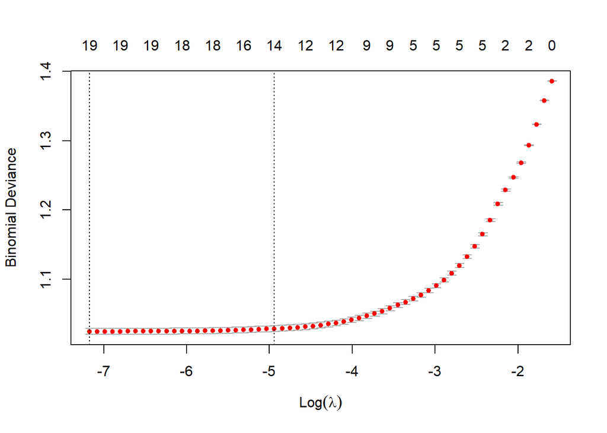

```r
cv.out = cv.glmnet(x,y, family = 'binomial', alpha = 1)
plot(cv.out)
```

Here, you can see the estimation of coefficients.

```r
bestlam = cv.out$lambda.min
predict(lasso.mod, s = bestlam, x, type = 'coefficients')
```

```
## 23 x 1 sparse Matrix of class "dgCMatrix"
##                                s1
## (Intercept)          -6.474539657
## (Intercept)           .
## HighBP                0.720671296
## HighChol              0.572016400
## CholCheck             0.947235119
## BMI                   0.076220513
## Smoker                .
## Stroke                0.067982769
## HeartDiseaseorAttack  0.223808312
## PhysActivity         -0.010368410
## Fruits               -0.016055050
## Veggies              -0.038694697
## HvyAlcoholConsump    -0.584918316
## AnyHealthcare         .
## NoDocbcCost           .
## GenHlth               0.585033513
## MentHlth             -0.004168176
## PhysHlth             -0.007001468
## DiffWalk              0.085059751
## Sex                   0.242210702
## Age                   0.155895817
## Education            -0.033747534
## Income               -0.059564218
```

# Fourth Problem

before we start, we need to determine the ‘Threshold’ which we use to address the diabetes.

```r
glm.prob2 = predict(glm.fit2,d, type = 'response')
cv.error = data.frame(matrix(data = NA, nrow = 9, ncol = 4))



for (i in 1:9){
  res = rep(0, nrow(d))
  res[glm.prob2 > i/10] = 1
  con_fit = confusionMatrix(reference = factor(d$Diabetes_binary), data = factor(res))
  cv.error[i, 2] = as.numeric(con_fit$overall[1])
  cv.error[i, 3] = con_fit$byClass[1]
  cv.error[i, 4] = con_fit$byClass[2]




}

names(cv.error) = c('Threshold', 'Accuracy', 'Specifity', 'Sensitivity')
cv.error$Threshold = 1:9/10
cv.error
```

```
##   Threshold  Accuracy Specifity Sensitivity
## 1       0.1 0.5965173 0.1992022   0.9938324
## 2       0.2 0.6782097 0.3894642   0.9669552
## 3       0.3 0.7255984 0.5294800   0.9217167
## 4       0.4 0.7461806 0.6351497   0.8572116
## 5       0.5 0.7482601 0.7289368   0.7675833
## 6       0.6 0.7328835 0.8105868   0.6551802
## 7       0.7 0.6933458 0.8806088   0.5060827
## 8       0.8 0.6308210 0.9423414   0.3193006
## 9       0.9 0.5496944 0.9855146   0.1138743
```

based on the table we use 0.45 as threshold.

## Prediction with Logistic Regression

```r
#####
# logistic
glm.prob = predict(glm.fit2,newdata = d2, type = 'response')
glm.prob[1:10]
```

```
##          1          2          3          4          5          6          7          8          9         10
## 0.93650303 0.08168252 0.80000905 0.40150057 0.49751094 0.47634222 0.47420735 0.69508878 0.88989507 0.19565068
```

```r
w = data.table(matrix(data = 0,nrow = nrow(d2), ncol = 2))
w$V1 = d2$Diabetes_binary
w$V2[glm.prob > 0.45] = 1
con_logistic = confusionMatrix(data = factor(w$V2),reference = factor(w$V1))
con_logistic$table
```

```
##           Reference
## Prediction      0      1
##          0 148508   6541
##          1  69826  28805
```

```r
con_logistic$overall[1]
```

```
##  Accuracy
## 0.6989633
```

```r
con_logistic$byClass[1:2]
```

```
## Sensitivity Specificity
##   0.6801872   0.8149437
```

##Prediction with Partial Least Square

```r
########
# pls

set.seed(1)
pls.fit = plsr(Diabetes_binary ~ ., data = d, scale = FALSE, validation = 'CV', type = 'binomial')
summary(pls.fit)
```

```
## Data:    X dimension: 70692 21
##  Y dimension: 70692 1
## Fit method: kernelpls
## Number of components considered: 21
##
## VALIDATION: RMSEP
## Cross-validated using 10 random segments.
##        (Intercept)  1 comps  2 comps  3 comps  4 comps  5 comps  6 comps  7 comps  8 comps  9 comps  10 comps
## CV             0.5   0.4706   0.4572   0.4392   0.4354    0.425   0.4202    0.417   0.4165    0.416    0.4157
## adjCV          0.5   0.4706   0.4572   0.4392   0.4355    0.425   0.4202    0.417   0.4165    0.416    0.4157
##        11 comps  12 comps  13 comps  14 comps  15 comps  16 comps  17 comps  18 comps  19 comps  20 comps
## CV       0.4156    0.4156    0.4156    0.4156    0.4156    0.4156    0.4156    0.4156    0.4156    0.4156
## adjCV    0.4156    0.4156    0.4156    0.4156    0.4156    0.4156    0.4156    0.4156    0.4156    0.4156
##        21 comps
## CV       0.4156
## adjCV    0.4156
##
## TRAINING: % variance explained
##                  1 comps  2 comps  3 comps  4 comps  5 comps  6 comps  7 comps  8 comps  9 comps  10 comps
## X                  47.24    71.14    76.24    91.89    97.49    98.83    99.02    99.28    99.35     99.42
## Diabetes_binary    11.43    16.40    22.86    24.17    27.76    29.38    30.46    30.64    30.81     30.91
##                  11 comps  12 comps  13 comps  14 comps  15 comps  16 comps  17 comps  18 comps  19 comps
## X                   99.49     99.54     99.60     99.65     99.72     99.78     99.85     99.89     99.93
## Diabetes_binary     30.94     30.94     30.95     30.95     30.95     30.95     30.95     30.95     30.95
##                  20 comps  21 comps
## X                   99.98    100.00
## Diabetes_binary     30.95     30.95
```

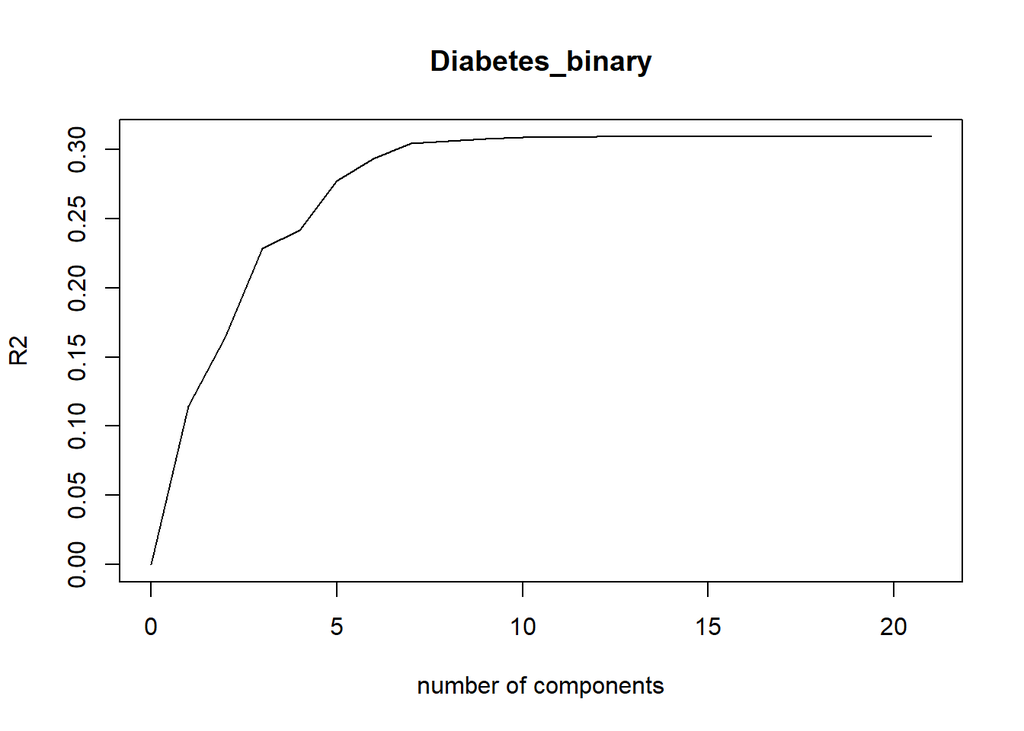

```r
validationplot(pls.fit, val.type = 'R2')
```

```r
pls.pred = predict(pls.fit, newdata = d2, ncomp = 10)
head(pls.pred,5)
```

```
## , , 10 comps
##
##   Diabetes_binary
## 1       0.9924090
## 2       0.1680573
## 3       0.7570673
## 4       0.4392928
## 5       0.5115458
```

```r
w$V3 = 0
w$V3[pls.pred > 0.45] = 1
con_pls = confusionMatrix(reference = factor(w$V1), data = factor(w$V3))
con_pls
```

```
## Confusion Matrix and Statistics
##
##           Reference
## Prediction      0      1
##          0 143109   5828
##          1  75225  29518
##
##                Accuracy : 0.6805
##                  95% CI : (0.6787, 0.6823)
##     No Information Rate : 0.8607
##     P-Value [Acc > NIR] : 1
##
##                   Kappa : 0.2691
##
##  Mcnemar's Test P-Value : <2e-16
##
##             Sensitivity : 0.6555
##             Specificity : 0.8351
##          Pos Pred Value : 0.9609
##          Neg Pred Value : 0.2818
##              Prevalence : 0.8607
##          Detection Rate : 0.5641
##    Detection Prevalence : 0.5871
##       Balanced Accuracy : 0.7453
##
##        'Positive' Class : 0
##
```

## Prediction with Lasso

```r
##########
#lasso
x2 = model.matrix(Diabetes_binary ~., data = d2, family = binomial)
lasso.fit = predict(lasso.mod, newx = x2, s = bestlam, type = 'response')
w$V4 = 0
w$V4[lasso.fit > 0.45] = 1
con_lasso = confusionMatrix(reference = factor(w$V1), data = factor(w$V4))
con_lasso
```

```
## Confusion Matrix and Statistics
##
##           Reference
## Prediction      0      1
##          0 148152   6492
##          1  70182  28854
##
##                Accuracy : 0.6978
##                  95% CI : (0.696, 0.6995)
##     No Information Rate : 0.8607
##     P-Value [Acc > NIR] : 1
##
##                   Kappa : 0.282
##
##  Mcnemar's Test P-Value : <2e-16
##
##             Sensitivity : 0.6786
##             Specificity : 0.8163
##          Pos Pred Value : 0.9580
##          Neg Pred Value : 0.2913
##              Prevalence : 0.8607
##          Detection Rate : 0.5840
##    Detection Prevalence : 0.6096
##       Balanced Accuracy : 0.7474
##
##        'Positive' Class : 0
##
```

```r
names(w) = c('y', 'logistic', 'pls', 'lasso')
```

## Prediction with Regression Tree

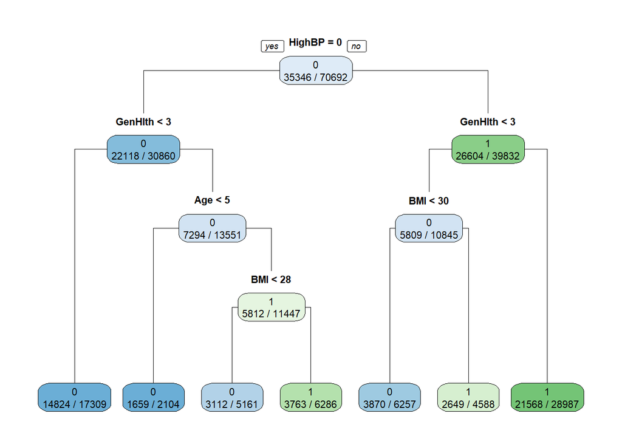

```r
#######
# tree

tree.fit = rpart(Diabetes_binary ~ ., method = 'class', data = d, control = rpart.control(maxdepth = 12))
rpart.plot(tree.fit, type = 1, extra = 2, cex = 0.7)
```

```r
tree.pred = predict(tree.fit, newdata = d2, type = 'class')
w$tree = tree.pred
con_tree = confusionMatrix(reference = factor(w$y), data = factor(w$tree))
con_tree
```

```
## Confusion Matrix and Statistics
##
##           Reference
## Prediction      0      1
##          0 144126   7366
##          1  74208  27980
##
##                Accuracy : 0.6784
##                  95% CI : (0.6766, 0.6803)
##     No Information Rate : 0.8607
##     P-Value [Acc > NIR] : 1
##
##                   Kappa : 0.252
##
##  Mcnemar's Test P-Value : <2e-16
##
##             Sensitivity : 0.6601
##             Specificity : 0.7916
##          Pos Pred Value : 0.9514
##          Neg Pred Value : 0.2738
##              Prevalence : 0.8607
##          Detection Rate : 0.5681
##    Detection Prevalence : 0.5972
##       Balanced Accuracy : 0.7259
##
##        'Positive' Class : 0
##
```

## Comparison of Methods

```r
ACC = data.frame(matrix(NA, nrow = 4, ncol = 4))
names(ACC) = c('Method', 'Accuracy', 'Sensitivity', 'Specifity')


ACC[1,] = c(Method = 'Logistic', Accuracy = round(con_logistic$overall[1],4), Sensitivity = round(con_logistic$byClass[1],4),
            Specifity = round(con_logistic$byClass[2],4))
ACC[2,] = c(Method = 'PLS', Accuracy = round(con_pls$overall[1],4), Sensitivity = round(con_pls$byClass[1],4),
            Specifity = round(con_pls$byClass[2],4))
ACC[3,] = c(Method = 'Lasso', Accuracy = round(con_lasso$overall[1],4), Sensitivity = round(con_lasso$byClass[1],4),
            Specifity = round(con_lasso$byClass[2],4))
ACC[4,] = c(Method = 'Tree', Accuracy = round(con_tree$overall[1],4), Sensitivity = round(con_tree$byClass[1],4),
            Specifity = round(con_tree$byClass[2],4))
ACC
```

```
##     Method Accuracy Sensitivity Specifity
## 1 Logistic    0.699      0.6802    0.8149
## 2      PLS   0.6805      0.6555    0.8351
## 3    Lasso   0.6978      0.6786    0.8163
## 4     Tree   0.6784      0.6601    0.7916
```